# Data Preparation With Pandas

**Pandas** is a Python library that provides tools to work with tabular and series data. *Series* data are 1-D data vectors with label. *Dataframes* are 2-D tabular structures with labels. There exist also a 3-D structures similarly that are called *Panles*. In this blog, we are focusing on dataframe structures.

## Importing Pandas

After installing the module, simply import Pandas using *import* command. It is a convention to import Pandas as pd:

```python
import pandas as pd
```

## Load and prepare the data

A critical step in any data analysis task is to prepare the data correctly. Here we load bike sharing history data that is available at [UCI Machine Learning Database](https://archive.ics.uci.edu/ml/datasets/Bike+Sharing+Dataset). You may download the data from [here](https://archive.ics.uci.edu/ml/machine-learning-databases/00275/Bike-Sharing-Dataset.zip) and extract it in the current folder.

```python
data_path = './hour.csv'

rides = pd.read_csv(data_path)
```

rides is a Pandas dataframe.

### Printing the data

We print the shape attribute to check the size:

```python
print(rides.shape)
```

```
(17379, 17)
```

This tells us that rides has 17 columns of data that are stored in 17379 rows. Now, let's print rides to see what is inside it. Since the numbers of columns and rows are large, we may use to print only part of the file:

```python
pd.set_option('display.max_rows', 10)
pd.set_option('display.max_columns', 10)
pd.set_option('display.width', 1000)

print(rides)
```

```
       instant      dteday  season  yr  mnth  ...   hum  windspeed  casual  registered  cnt
0            1  2011-01-01       1   0     1  ...  0.81     0.0000       3          13   16
1            2  2011-01-01       1   0     1  ...  0.80     0.0000       8          32   40
2            3  2011-01-01       1   0     1  ...  0.80     0.0000       5          27   32
3            4  2011-01-01       1   0     1  ...  0.75     0.0000       3          10   13
4            5  2011-01-01       1   0     1  ...  0.75     0.0000       0           1    1
...        ...         ...     ...  ..   ...  ...   ...        ...     ...         ...  ...
17374    17375  2012-12-31       1   1    12  ...  0.60     0.1642      11         108  119
17375    17376  2012-12-31       1   1    12  ...  0.60     0.1642       8          81   89
17376    17377  2012-12-31       1   1    12  ...  0.60     0.1642       7          83   90
17377    17378  2012-12-31       1   1    12  ...  0.56     0.1343      13          48   61
17378    17379  2012-12-31       1   1    12  ...  0.65     0.1343      12          37   49

[17379 rows x 17 columns]
```

Another way to see part of the table is to use *head* and *tail* methods:

```python
rides.head()
```

|  | instant | dteday | season | yr | mnth | ... | hum | windspeed | casual | registered | cnt |
| --- | --- | --- | --- | --- | --- | --- | --- | --- | --- | --- | --- |
| 0 | 1 | 2011-01-01 | 1 | 0 | 1 | ... | 0.81 | 0.0 | 3 | 13 | 16 |
| 1 | 2 | 2011-01-01 | 1 | 0 | 1 | ... | 0.80 | 0.0 | 8 | 32 | 40 |
| 2 | 3 | 2011-01-01 | 1 | 0 | 1 | ... | 0.80 | 0.0 | 5 | 27 | 32 |
| 3 | 4 | 2011-01-01 | 1 | 0 | 1 | ... | 0.75 | 0.0 | 3 | 10 | 13 |
| 4 | 5 | 2011-01-01 | 1 | 0 | 1 | ... | 0.75 | 0.0 | 0 | 1 | 1 |

5 rows × 17 columns

```python
rides.tail()
```

|  | instant | dteday | season | yr | mnth | ... | hum | windspeed | casual | registered | cnt |
| --- | --- | --- | --- | --- | --- | --- | --- | --- | --- | --- | --- |
| 17374 | 17375 | 2012-12-31 | 1 | 1 | 12 | ... | 0.60 | 0.1642 | 11 | 108 | 119 |
| 17375 | 17376 | 2012-12-31 | 1 | 1 | 12 | ... | 0.60 | 0.1642 | 8 | 81 | 89 |
| 17376 | 17377 | 2012-12-31 | 1 | 1 | 12 | ... | 0.60 | 0.1642 | 7 | 83 | 90 |
| 17377 | 17378 | 2012-12-31 | 1 | 1 | 12 | ... | 0.56 | 0.1343 | 13 | 48 | 61 |
| 17378 | 17379 | 2012-12-31 | 1 | 1 | 12 | ... | 0.65 | 0.1343 | 12 | 37 | 49 |

5 rows × 17 columns

The default number of rows considered is 5. It is possible to show a specific number of rows:

```python
rides.head(10)
```

|  | instant | dteday | season | yr | mnth | ... | hum | windspeed | casual | registered | cnt |
| --- | --- | --- | --- | --- | --- | --- | --- | --- | --- | --- | --- |
| 0 | 1 | 2011-01-01 | 1 | 0 | 1 | ... | 0.81 | 0.0000 | 3 | 13 | 16 |
| 1 | 2 | 2011-01-01 | 1 | 0 | 1 | ... | 0.80 | 0.0000 | 8 | 32 | 40 |
| 2 | 3 | 2011-01-01 | 1 | 0 | 1 | ... | 0.80 | 0.0000 | 5 | 27 | 32 |
| 3 | 4 | 2011-01-01 | 1 | 0 | 1 | ... | 0.75 | 0.0000 | 3 | 10 | 13 |
| 4 | 5 | 2011-01-01 | 1 | 0 | 1 | ... | 0.75 | 0.0000 | 0 | 1 | 1 |
| 5 | 6 | 2011-01-01 | 1 | 0 | 1 | ... | 0.75 | 0.0896 | 0 | 1 | 1 |
| 6 | 7 | 2011-01-01 | 1 | 0 | 1 | ... | 0.80 | 0.0000 | 2 | 0 | 2 |
| 7 | 8 | 2011-01-01 | 1 | 0 | 1 | ... | 0.86 | 0.0000 | 1 | 2 | 3 |
| 8 | 9 | 2011-01-01 | 1 | 0 | 1 | ... | 0.75 | 0.0000 | 1 | 7 | 8 |
| 9 | 10 | 2011-01-01 | 1 | 0 | 1 | ... | 0.76 | 0.0000 | 8 | 6 | 14 |

10 rows × 17 columns

### Accessing the data

Dataframe object is not callable and we cannot use indexing to directly access an entry in the table. Instead, we can use *iloc* method for slice indexing. It returns a dataframe object that is a slice of the original table:

```python
rides.iloc[0:2, 10:13]
```

|  | temp | atemp | hum |
| --- | --- | --- | --- |
| 0 | 0.24 | 0.2879 | 0.81 |
| 1 | 0.22 | 0.2727 | 0.80 |

Similarly, we can use *loc* method but instead of giving indices for slicing, we pass the columns'/rows' labels:

```python
rides.loc[[0,1,2], ['temp', 'atemp', 'hum']]
```

|  | temp | atemp | hum |
| --- | --- | --- | --- |
| 0 | 0.24 | 0.2879 | 0.81 |
| 1 | 0.22 | 0.2727 | 0.80 |
| 2 | 0.22 | 0.2727 | 0.80 |

The ':' is inclusive, so 0:2 means lables from '0' to '2' and we can rewrite the previous statement as follows:

```python
rides.loc[0:2, 'temp':'hum']
```

|  | temp | atemp | hum |
| --- | --- | --- | --- |
| 0 | 0.24 | 0.2879 | 0.81 |
| 1 | 0.22 | 0.2727 | 0.80 |
| 2 | 0.22 | 0.2727 | 0.80 |

It is possible to slice rows:

```python
rides[0:10]
```

|  | instant | dteday | season | yr | mnth | ... | hum | windspeed | casual | registered | cnt |
| --- | --- | --- | --- | --- | --- | --- | --- | --- | --- | --- | --- |
| 0 | 1 | 2011-01-01 | 1 | 0 | 1 | ... | 0.81 | 0.0000 | 3 | 13 | 16 |
| 1 | 2 | 2011-01-01 | 1 | 0 | 1 | ... | 0.80 | 0.0000 | 8 | 32 | 40 |
| 2 | 3 | 2011-01-01 | 1 | 0 | 1 | ... | 0.80 | 0.0000 | 5 | 27 | 32 |
| 3 | 4 | 2011-01-01 | 1 | 0 | 1 | ... | 0.75 | 0.0000 | 3 | 10 | 13 |
| 4 | 5 | 2011-01-01 | 1 | 0 | 1 | ... | 0.75 | 0.0000 | 0 | 1 | 1 |
| 5 | 6 | 2011-01-01 | 1 | 0 | 1 | ... | 0.75 | 0.0896 | 0 | 1 | 1 |
| 6 | 7 | 2011-01-01 | 1 | 0 | 1 | ... | 0.80 | 0.0000 | 2 | 0 | 2 |
| 7 | 8 | 2011-01-01 | 1 | 0 | 1 | ... | 0.86 | 0.0000 | 1 | 2 | 3 |
| 8 | 9 | 2011-01-01 | 1 | 0 | 1 | ... | 0.75 | 0.0000 | 1 | 7 | 8 |
| 9 | 10 | 2011-01-01 | 1 | 0 | 1 | ... | 0.76 | 0.0000 | 8 | 6 | 14 |

10 rows × 17 columns

and finally, it is possible to call a dataframe object by column key name. This will return a Series object:

```python
rides['windspeed']
```

```
0        0.0000
1        0.0000
2        0.0000
3        0.0000
4        0.0000
          ...
17374    0.1642
17375    0.1642
17376    0.1642
17377    0.1343
17378    0.1343
Name: windspeed, Length: 17379, dtype: float64
```

## Plotting the data

This dataset we are looking at has the number of riders for each hour of each day from January 1 2011 to December 31 2012. The number of riders is split between casual and registered, summed up in the `cnt` column. You can see the first few rows of the data above.

To plot the cnt values over time we can call the plot method. x and y and title attributes can be passed to the method. Here, we also switched on the grid:

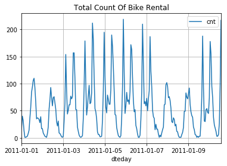

```python
plt_10_days = rides[:10*24].plot(x='dteday', y='cnt', \
                                 title='Total Count Of Bike Rental', \
                                 grid=True)
```

Above is a plot showing the number of bike riders over the first 10 days or so in the data set. (Some days don't have exactly 24 entries in the data set, so it's not exactly 10 days.) We can see the hourly rentals here. This data is pretty complicated! The weekends have lower over all ridership and there are spikes when people are biking to and from work during the week. Looking at the data above, we also have information about temperature, humidity, and windspeed, all of these likely affecting the number of riders.

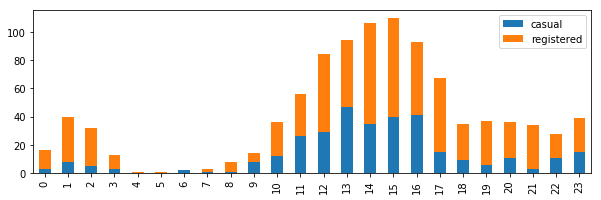

```python
plt_bar = rides.iloc[0:24,14:16].plot.bar(stacked=True,figsize=(10,3))
```

The cumulative summation of additive quantities is an intersting feature that can be readily obtained:

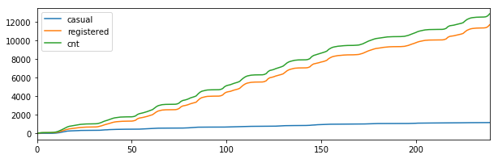

```python
plt_cumsum = rides.iloc[:10*24, 14:17].cumsum().plot(figsize=(10,3))
```

Finally, with stochastic data it is interested to see the moving average of data in a specific time window. We compare two time windows here, the 1-day length and 30-day length for temperature values (normalised by deviding to 41°C):

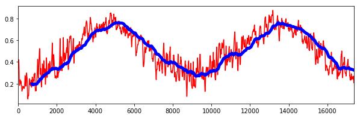

```python
tmp_plot = rides['temp'].rolling(24).mean().plot(color='red',figsize=(10,3))
tmp_plot = tmp_plot.plot(rides['temp'].rolling(30*24).mean(),\
                         linewidth=5, color='blue')
```

Similarly, we plot the moving average for total rental count numbers. The plot is for the about two years of data.

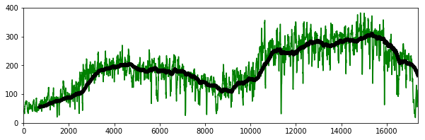

```python
cnt_plot = rides['cnt'].rolling(24).mean().plot(color='green',figsize=(10,3))
cnt_plot = cnt_plot.plot(rides['cnt'].rolling(30*24).mean(),\
                         linewidth=5, color='black')
```

### Dummy variables

Here we have some categorical variables like season, weather, month. To include these in modeling, we need to make binary dummy variables. This is simple to do with Pandas thanks to `get_dummies()`. We can use the drop method to remove those columns (nd others we don't need) from the dataframe:

```python
dummy_fields = ['season', 'weathersit', 'mnth', 'hr', 'weekday']
for each in dummy_fields:
    dummies = pd.get_dummies(rides[each], prefix=each, drop_first=False)
    rides = pd.concat([rides, dummies], axis=1)

fields_to_drop = ['instant', 'dteday', 'season', 'weathersit',
                  'weekday', 'atemp', 'mnth', 'workingday', 'hr']#,
data = rides.drop(fields_to_drop, axis=1)
data.head()
```

|  | yr | holiday | temp | hum | windspeed | ... | weekday_2 | weekday_3 | weekday_4 | weekday_5 | weekday_6 |
| --- | --- | --- | --- | --- | --- | --- | --- | --- | --- | --- | --- |
| 0 | 0 | 0 | 0.24 | 0.81 | 0.0 | ... | 0 | 0 | 0 | 0 | 1 |
| 1 | 0 | 0 | 0.22 | 0.80 | 0.0 | ... | 0 | 0 | 0 | 0 | 1 |
| 2 | 0 | 0 | 0.22 | 0.80 | 0.0 | ... | 0 | 0 | 0 | 0 | 1 |
| 3 | 0 | 0 | 0.24 | 0.75 | 0.0 | ... | 0 | 0 | 0 | 0 | 1 |
| 4 | 0 | 0 | 0.24 | 0.75 | 0.0 | ... | 0 | 0 | 0 | 0 | 1 |

### Scaling target variables

It is normally needed to make the variables in the same range, when performing a similar analysis to data with various scales. That is, we'll shift and scale the variables such that they have zero mean and a standard deviation of 1.

```python
quant_features = ['casual', 'registered', 'cnt', 'temp', 'hum', 'windspeed']

scaled_features = {}

for each in quant_features:
    mean, std = data[each].mean(), data[each].std()
    scaled_features[each] = [mean, std]
    data.loc[:, each] = (data[each] - mean)/std
```

Finally, we plot the quantity features before and after the normalization for comparison.

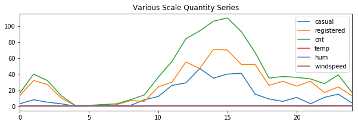

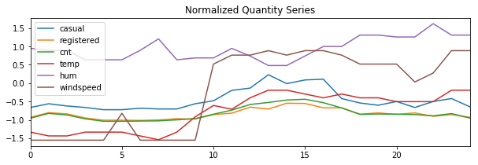

```python
plt_raw = rides.loc[:24, quant_features].plot(figsize=(10,3),\
                                              title='Various Scale Quantity Series')
plt_nrm = data.loc[:24, quant_features].plot(figsize=(10,3),\
                                              title='Normalized Quantity Series')
```